# 191113(11주차)_복습_강연욱

강연욱

11/17/2019

# 1.

## 1-1. 귀무가설(Ho)과 대립가설(Ha)을 제시하라.

> Ho(귀무가설) = 두 집단의 암기법에는 차이가 없다.  
> Ha(대립가설) = 두 집단의 암기법에는 차이가 있다.

## 1-2. 두 모집단이 정규분포를 따르는지 확인하고, 그 이유를 귀무가설(Ho)과 대립가설(Ha)을 제시하여 설명하라.

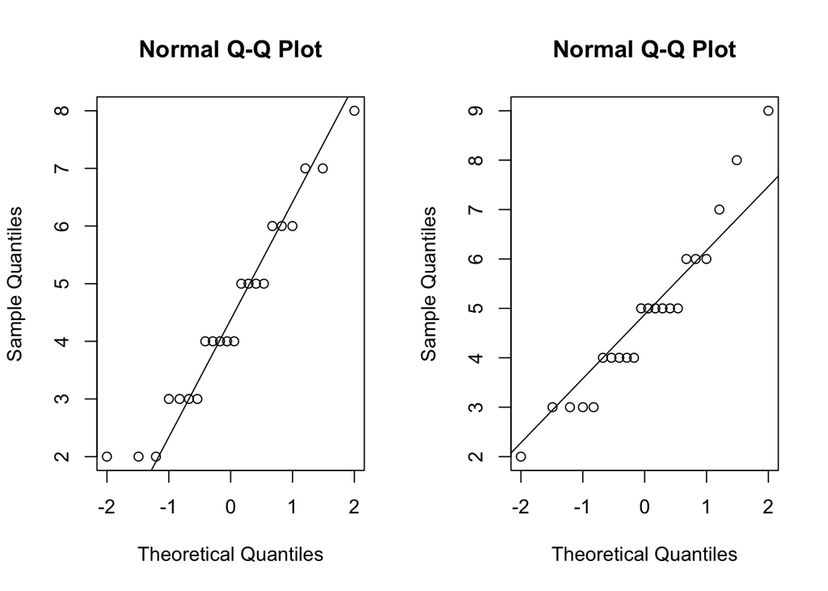

```r
par(mfrow = c(1,2))
a_group <- c(6,7,3,8,4,4,7,4,2,5,4,3,5,2,6,5,2,3,5,6,3,4)
b_group <- c(7,6,5,8,6,4,9,4,5,6,4,5,3,2,3,4,3,4,5,3,5,5)
qqnorm(a_group) ; qqline(a_group)
qqnorm(b_group) ; qqline(b_group)
```

> 두 그래프 모두 정규분포를 따른다.  
> Ho(귀무가설) = 두 집단의 암기법에는 차이가 없다.  
> Ha(대립가설) = 두 집단의 암기법에는 차이가 있다.

## 1-3. 두 모집단의 분포가 같은지 귀무가설과 대립가설을 제시하여 설명하라.

```r
var.test(a_group, b_group)
```

```
##
##  F test to compare two variances
##
## data:  a_group and b_group
## F = 1.003, num df = 21, denom df = 21, p-value = 0.9946
## alternative hypothesis: true ratio of variances is not equal to 1
## 95 percent confidence interval:
##  0.4164127 2.4157366
## sample estimates:
## ratio of variances
##           1.002967
```

> P-value>0.05 = Ho 기각 X = 두 집단의 분산의 차이가 없다.  
> Ho(귀무가설) = 두 집단의 암기법에는 차이가 없다.  
> Ha(대립가설) = 두 집단의 암기법에는 차이가 있다.

## 1-4. (1-2,1-3,1-4)에서 확인한 분포에 대한 특징들을 이용하여, (1-1)의 대립가설을 채택할 수 있는지 확인하라.(단,t분포,양측검정)

```r
t.test(a_group, b_group, alternative = "two.sided", var.equal = TRUE)
```

```
##
##  Two Sample t-test
##
## data:  a_group and b_group
## t = -0.70553, df = 42, p-value = 0.4844
## alternative hypothesis: true difference in means is not equal to 0
## 95 percent confidence interval:
##  -1.4037680  0.6764953
## sample estimates:
## mean of x mean of y
##  4.454545  4.818182
```